# Assignment 2 - Naive Bayes Model

Marketing 2

19 June 2026

# 1. Introduction

This R Markdown document presents the Naive Bayes classification model used to predict customer recommendation behaviour for Gelugor Fashion Store. The target variable is `recommend_index`, where customers are classified as either `Recommend` or `Not_Recommend`. The `Not_Recommend` class is treated as the positive class in the confusion matrix because it represents loyalty-risk customers who may require targeted business improvement actions.

# 2. Load Dataset

```r
final_ml_dataset <- read_csv("final_ml_dataset.csv")

dim(final_ml_dataset)
```

```
## [1] 22627   175
```

```r
str(final_ml_dataset)
```

```
## spc_tbl_ [22,627 × 175] (S3: spec_tbl_df/tbl_df/tbl/data.frame)
##  $ recommend_index     : num [1:22627] 1 1 0 1 1 1 1 1 1 1 ...
##  $ rating              : num [1:22627] 5 5 1 5 5 4 5 5 5 5 ...
##  $ sentiment_score     : num [1:22627] 1 3 1 4 -1 4 8 1 5 8 ...
##  $ age                 : num [1:22627] 40 62 47 45 37 43 79 34 49 49 ...
##  $ alike_feedback_count: num [1:22627] 0 12 3 0 0 0 4 2 4 0 ...
##  $ age_group           : chr [1:22627] "middle" "senior" "middle" "middle" ...
##  $ department_name     : chr [1:22627] "Bottoms" "Tops" "Bottoms" "Bottoms" ...
##  $ class_name          : chr [1:22627] "Jeans" "Blouses" "Skirts" "Pants" ...
##  $ feedback_count_group: num [1:22627] 1 1 1 1 1 1 1 1 1 1 ...
##  $ division_name       : chr [1:22627] "General" "General Petite" "General Petite" "General Petite" ...
##  $ amaze               : num [1:22627] 1 0 0 0 0 0 0 0 0 0 ...
##  $ fit                 : num [1:22627] 1 1 0 1 1 0 1 0 0 0 ...
##  $ jeans               : num [1:22627] 1 0 0 0 0 1 0 0 0 0 ...
##  $ pair                : num [1:22627] 1 0 0 0 0 0 0 0 0 0 ...
##  $ purchase            : num [1:22627] 1 0 0 0 1 0 0 0 0 0 ...
##  $ color               : num [1:22627] 0 1 0 1 0 1 1 0 0 0 ...
##  $ fall                : num [1:22627] 0 1 0 0 0 0 0 0 0 0 ...
##  $ flatter             : num [1:22627] 0 1 0 0 0 0 0 0 0 0 ...
##  $ lovely              : num [1:22627] 0 1 0 0 0 0 0 0 0 1 ...
##  $ model               : num [1:22627] 0 1 0 0 0 0 0 0 0 0 ...
##  $ photo               : num [1:22627] 0 1 0 0 0 0 0 0 0 0 ...
##  $ shame               : num [1:22627] 0 1 0 0 0 0 0 0 0 0 ...
##  $ soft                : num [1:22627] 0 1 0 0 0 0 1 0 0 1 ...
##  $ true                : num [1:22627] 0 1 0 0 0 0 1 0 0 0 ...
##  $ unique              : num [1:22627] 0 1 0 0 0 0 1 1 0 0 ...
##  $ winter              : num [1:22627] 0 1 0 0 0 0 0 0 0 0 ...
##  $ design              : num [1:22627] 0 0 1 0 0 0 0 0 0 0 ...
##  $ love                : num [1:22627] 0 0 1 1 1 1 1 0 1 1 ...
##  $ meh                 : num [1:22627] 0 0 1 0 0 0 0 0 0 0 ...
##  $ black               : num [1:22627] 0 0 0 1 0 0 0 0 0 0 ...
##  $ buy                 : num [1:22627] 0 0 0 1 0 0 0 0 1 0 ...
##  $ perfect             : num [1:22627] 0 0 0 1 0 0 0 0 0 0 ...
##  $ size                : num [1:22627] 0 0 0 1 1 0 1 0 0 1 ...
##  $ slightly            : num [1:22627] 0 0 0 1 0 0 0 0 0 0 ...
##  $ look                : num [1:22627] 0 0 0 0 1 0 0 0 0 0 ...
##  $ odd                 : num [1:22627] 0 0 0 0 1 0 0 0 0 0 ...
##  $ piece               : num [1:22627] 0 0 0 0 1 1 0 0 0 0 ...
##  $ simple              : num [1:22627] 0 0 0 0 0 1 0 0 0 0 ...
##  $ staple              : num [1:22627] 0 0 0 0 0 1 0 0 0 0 ...
```

[output cut: 225 more lines]

```
##   ..   shapeless = col_double(),
##   ..   concept = col_double(),
##   ..   instruction = col_double(),
##   ..   needless = col_double(),
##   ..   barely = col_double(),
##   ..   additionally = col_double(),
##   ..   asap = col_double(),
##   ..   blah = col_double(),
##   ..   potato = col_double(),
##   ..   badly = col_double(),
##   ..   ruin = col_double(),
##   ..   drab = col_double(),
##   ..   cheaply = col_double()
##   .. )
##  - attr(*, "problems")=<externalptr>
```

```r
head(final_ml_dataset)
```

```
## # A tibble: 6 × 175
##   recommend_index rating sentiment_score   age alike_feedback_count age_group
##             <dbl>  <dbl>           <dbl> <dbl>                <dbl> <chr>
## 1               1      5               1    40                    0 middle
## 2               1      5               3    62                   12 senior
## 3               0      1               1    47                    3 middle
## 4               1      5               4    45                    0 middle
## 5               1      5              -1    37                    0 middle
## 6               1      4               4    43                    0 middle
## # ℹ 169 more variables: department_name <chr>, class_name <chr>,
## #   feedback_count_group <dbl>, division_name <chr>, amaze <dbl>, fit <dbl>,
## #   jeans <dbl>, pair <dbl>, purchase <dbl>, color <dbl>, fall <dbl>,
## #   flatter <dbl>, lovely <dbl>, model <dbl>, photo <dbl>, shame <dbl>,
## #   soft <dbl>, true <dbl>, unique <dbl>, winter <dbl>, design <dbl>,
## #   love <dbl>, meh <dbl>, black <dbl>, buy <dbl>, perfect <dbl>, size <dbl>,
## #   slightly <dbl>, look <dbl>, odd <dbl>, piece <dbl>, simple <dbl>, …
```

## Target Distribution

```r
table(final_ml_dataset$recommend_index)
```

```
##
##     0     1
##  4101 18526
```

```r
prop.table(table(final_ml_dataset$recommend_index))
```

```
##
##         0         1
## 0.1812436 0.8187564
```

# 3. Data Preparation

The target variable is converted into a factor with two levels: `Not_Recommend` and `Recommend`. Character variables are also converted into factors before dummy encoding.

```r
nb_data <- final_ml_dataset %>%
  mutate(
    recommend_index = factor(
      as.character(recommend_index),
      levels = c("0", "1"),
      labels = c("Not_Recommend", "Recommend")
    ),
    across(where(is.character), as.factor)
  )

table(nb_data$recommend_index)
```

```
##
## Not_Recommend     Recommend
##          4101         18526
```

```r
prop.table(table(nb_data$recommend_index))
```

```
##
## Not_Recommend     Recommend
##     0.1812436     0.8187564
```

```r
str(nb_data)
```

```
## tibble [22,627 × 175] (S3: tbl_df/tbl/data.frame)
##  $ recommend_index     : Factor w/ 2 levels "Not_Recommend",..: 2 2 1 2 2 2 2 2 2 2 ...
##  $ rating              : num [1:22627] 5 5 1 5 5 4 5 5 5 5 ...
##  $ sentiment_score     : num [1:22627] 1 3 1 4 -1 4 8 1 5 8 ...
##  $ age                 : num [1:22627] 40 62 47 45 37 43 79 34 49 49 ...
##  $ alike_feedback_count: num [1:22627] 0 12 3 0 0 0 4 2 4 0 ...
##  $ age_group           : Factor w/ 5 levels "adult","elderly",..: 3 4 3 3 3 3 2 1 3 3 ...
##  $ department_name     : Factor w/ 6 levels "Bottoms","Dresses",..: 1 5 1 1 3 5 5 5 5 5 ...
##  $ class_name          : Factor w/ 20 levels "Blouses","Casual bottoms",..: 8 1 16 14 19 18 18 9 5 9 ...
##  $ feedback_count_group: num [1:22627] 1 1 1 1 1 1 1 1 1 1 ...
##  $ division_name       : Factor w/ 3 levels "General","General Petite",..: 1 2 2 2 3 1 1 1 2 1 ...
##  $ amaze               : num [1:22627] 1 0 0 0 0 0 0 0 0 0 ...
##  $ fit                 : num [1:22627] 1 1 0 1 1 0 1 0 0 0 ...
##  $ jeans               : num [1:22627] 1 0 0 0 0 1 0 0 0 0 ...
##  $ pair                : num [1:22627] 1 0 0 0 0 0 0 0 0 0 ...
```

[output cut: 86 more lines]

# 4. Stratified Train-Test Split

The dataset is split into 70% training data and 30% testing data using stratified sampling. This helps preserve the proportion of `Recommend` and `Not_Recommend` classes in both datasets.

```r
set.seed(123)

train_index <- createDataPartition(
  nb_data$recommend_index,
  p = 0.7,
  list = FALSE
)

nb_train <- nb_data[train_index, ]
nb_test  <- nb_data[-train_index, ]

dim(nb_train)
```

```
## [1] 15840   175
```

```r
dim(nb_test)
```

```
## [1] 6787  175
```

```r
table(nb_train$recommend_index)
```

```
##
## Not_Recommend     Recommend
##          2871         12969
```

```r
table(nb_test$recommend_index)
```

```
##
## Not_Recommend     Recommend
##          1230          5557
```

# 5. Dummy Encoding

Naive Bayes requires predictors to be in a suitable numeric format. Therefore, categorical predictors are transformed into dummy variables using `dummyVars()`.

```r
nb_train_x_raw <- nb_train %>%
  select(-recommend_index)

nb_test_x_raw <- nb_test %>%
  select(-recommend_index)

dummy_model <- dummyVars(
  ~ .,
  data = nb_train_x_raw,
  fullRank = TRUE
)

nb_train_x <- predict(dummy_model, nb_train_x_raw) %>%
  as.data.frame()

nb_test_x <- predict(dummy_model, nb_test_x_raw) %>%
  as.data.frame()

nb_train_y <- nb_train$recommend_index
nb_test_y <- nb_test$recommend_index

colnames(nb_train_x) <- make.names(colnames(nb_train_x), unique = TRUE)
colnames(nb_test_x) <- make.names(colnames(nb_test_x), unique = TRUE)

dim(nb_train_x)
```

```
## [1] 15840   200
```

```r
dim(nb_test_x)
```

```
## [1] 6787  200
```

# 6. Remove Near-Zero Variance Features

Near-zero variance features provide very little useful information to the model. These features are removed to improve model stability and reduce unnecessary predictors.

```r
nzv_cols <- nearZeroVar(nb_train_x)

length(nzv_cols)
```

```
## [1] 144
```

```r
if (length(nzv_cols) > 0) {
  nb_train_x <- nb_train_x[, -nzv_cols]
  nb_test_x <- nb_test_x[, -nzv_cols]
}

dim(nb_train_x)
```

```
## [1] 15840    56
```

```r
dim(nb_test_x)
```

```
## [1] 6787   56
```

# 7. Train Naive Bayes Model

The Naive Bayes model is trained using the processed training dataset. This model estimates class probabilities based on the relationship between predictor features and the target class.

```r
nb_model <- naiveBayes(
  x = nb_train_x,
  y = nb_train_y
)

print(nb_model)
```

```
##
## Naive Bayes Classifier for Discrete Predictors
##
## Call:
## naiveBayes.default(x = nb_train_x, y = nb_train_y)
##
## A-priori probabilities:
## nb_train_y
## Not_Recommend     Recommend
##       0.18125       0.81875
##
## Conditional probabilities:
##                rating
## nb_train_y          [,1]      [,2]
##   Not_Recommend 2.303030 0.8513903
##   Recommend     4.599121 0.6366862
##
##                sentiment_score
## nb_train_y           [,1]     [,2]
##   Not_Recommend 0.6433299 2.410255
##   Recommend     3.3023363 2.482256
##
##                age
## nb_train_y          [,1]     [,2]
##   Not_Recommend 42.35911 11.67601
##   Recommend     43.31344 12.29084
##
##                alike_feedback_count
## nb_train_y          [,1]     [,2]
##   Not_Recommend 3.352490 6.617348
##   Recommend     2.457013 5.573124
##
##                age_group.middle
## nb_train_y           [,1]      [,2]
##   Not_Recommend 0.4461860 0.4971822
##   Recommend     0.4316447 0.4953246
##
##                age_group.senior
## nb_train_y           [,1]      [,2]
##   Not_Recommend 0.1964472 0.3973798
```

[output cut: 236 more lines]

```
##
##                super
## nb_train_y            [,1]      [,2]
##   Not_Recommend 0.05085336 0.2197365
##   Recommend     0.08520318 0.2791946
##
##                arm
## nb_train_y            [,1]      [,2]
##   Not_Recommend 0.08011146 0.2715130
##   Recommend     0.04880870 0.2154762
##
##                shape
## nb_train_y            [,1]      [,2]
##   Not_Recommend 0.07836991 0.2687996
##   Recommend     0.04749788 0.2127095
```

# 8. Test Set Prediction

The trained Naive Bayes model is applied to the test dataset. Both predicted classes and predicted probabilities are generated.

```r
nb_pred <- predict(nb_model, newdata = nb_test_x)
nb_prob <- predict(nb_model, newdata = nb_test_x, type = "raw")

head(nb_pred)
```

```
## [1] Recommend Recommend Recommend Recommend Recommend Recommend
## Levels: Not_Recommend Recommend
```

```r
head(nb_prob)
```

```
##      Not_Recommend Recommend
## [1,]  3.329261e-09 1.0000000
## [2,]  2.121300e-06 0.9999979
## [3,]  4.685154e-08 1.0000000
## [4,]  1.007252e-02 0.9899275
## [5,]  4.483948e-06 0.9999955
## [6,]  4.165581e-05 0.9999583
```

# 9. Confusion Matrix

The confusion matrix evaluates how many customers were correctly and incorrectly classified. The positive class is set as `Not_Recommend` because this group represents loyalty-risk customers.

```r
nb_cm <- confusionMatrix(
  data = nb_pred,
  reference = nb_test_y,
  positive = "Not_Recommend"
)

print(nb_cm)
```

```
## Confusion Matrix and Statistics
##
##                Reference
## Prediction      Not_Recommend Recommend
##   Not_Recommend          1073       924
##   Recommend               157      4633
##
##                Accuracy : 0.8407
##                  95% CI : (0.8318, 0.8494)
##     No Information Rate : 0.8188
##     P-Value [Acc > NIR] : 9.986e-07
##
##                   Kappa : 0.5681
##
##  Mcnemar's Test P-Value : < 2.2e-16
##
##             Sensitivity : 0.8724
##             Specificity : 0.8337
##          Pos Pred Value : 0.5373
##          Neg Pred Value : 0.9672
##              Prevalence : 0.1812
##          Detection Rate : 0.1581
##    Detection Prevalence : 0.2942
##       Balanced Accuracy : 0.8530
##
##        'Positive' Class : Not_Recommend
##
```

## Key Classification Metrics

```r
accuracy <- nb_cm$overall["Accuracy"]
precision <- nb_cm$byClass["Pos Pred Value"]
recall <- nb_cm$byClass["Sensitivity"]
f1_score <- 2 * (precision * recall) / (precision + recall)

accuracy
```

```
##  Accuracy
## 0.8407249
```

```r
precision
```

```
## Pos Pred Value
##       0.537306
```

```r
recall
```

```
## Sensitivity
##   0.8723577
```

```r
f1_score
```

```
## Pos Pred Value
##      0.6650139
```

## Save Confusion Matrix Table

```r
nb_cm_table <- as.data.frame(nb_cm$table)

nb_cm_table
```

```
##      Prediction     Reference Freq
## 1 Not_Recommend Not_Recommend 1073
## 2     Recommend Not_Recommend  157
## 3 Not_Recommend     Recommend  924
## 4     Recommend     Recommend 4633
```

```r
write_csv(nb_cm_table, "NB_ConfusionMatrix_Table.csv")
```

## Confusion Matrix Heatmap

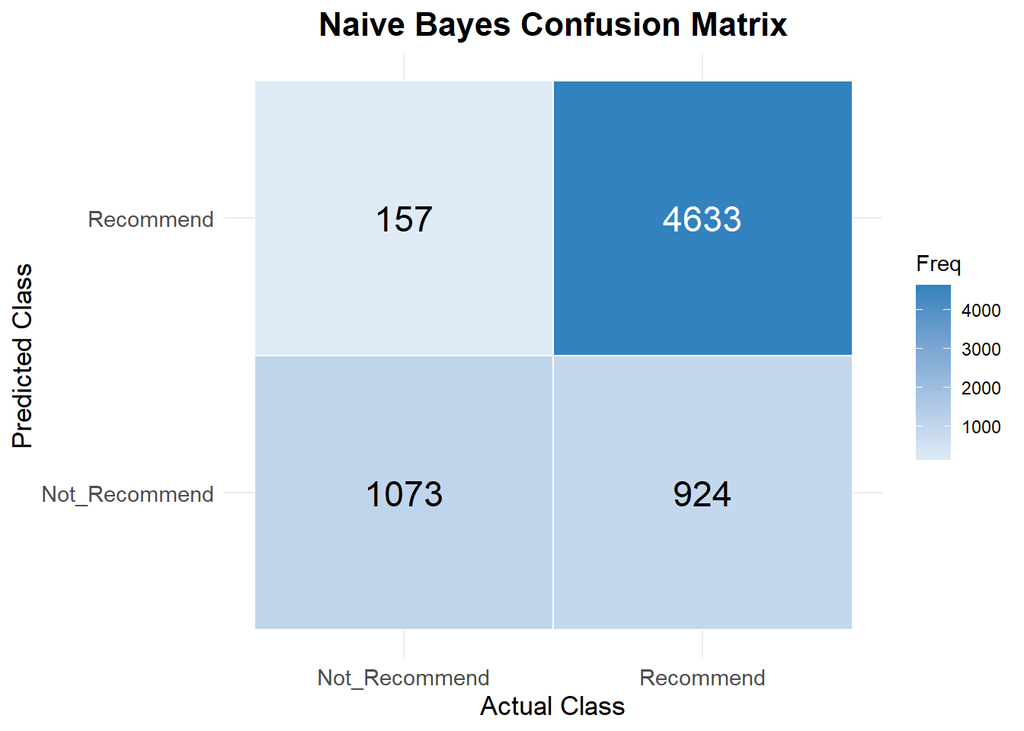

```r
nb_cm_plot <- ggplot(nb_cm_table, aes(x = Reference, y = Prediction, fill = Freq)) +
  geom_tile(color = "white", linewidth = 0.5) +
  geom_text(
    aes(
      label = Freq,
      colour = ifelse(Freq > max(Freq) / 2, "white", "black")
    ),
    size = 6
  ) +
  scale_colour_identity() +
  scale_fill_gradient(
    low = "#DEEBF7",
    high = "#3182BD"
  ) +
  labs(
    title = "Naive Bayes Confusion Matrix",
    x = "Actual Class",
    y = "Predicted Class",
    fill = "Freq"
  ) +
  theme_minimal() +
  theme(
    plot.title = element_text(size = 16, face = "bold", hjust = 0.5),
    axis.title = element_text(size = 13),
    axis.text = element_text(size = 11)
  )

nb_cm_plot
```

```r
ggsave(
  "NB_ConfusionMatrix.png",
  nb_cm_plot,
  width = 6,
  height = 5,
  dpi = 300
)
```

# 10. ROC Curve and AUC

The ROC curve evaluates how well the Naive Bayes model separates `Recommend` and `Not_Recommend` customers. This plot uses the probability of the `Recommend` class to match the Logistic Regression ROC plot style.

```r
roc_nb <- roc(
  response = nb_test_y,
  predictor = nb_prob[, "Recommend"],
  levels = c("Not_Recommend", "Recommend"),
  direction = "<"
)

auc_value <- auc(roc_nb)

auc_value
```

```
## Area under the curve: 0.9225
```

## ROC Curve Plot

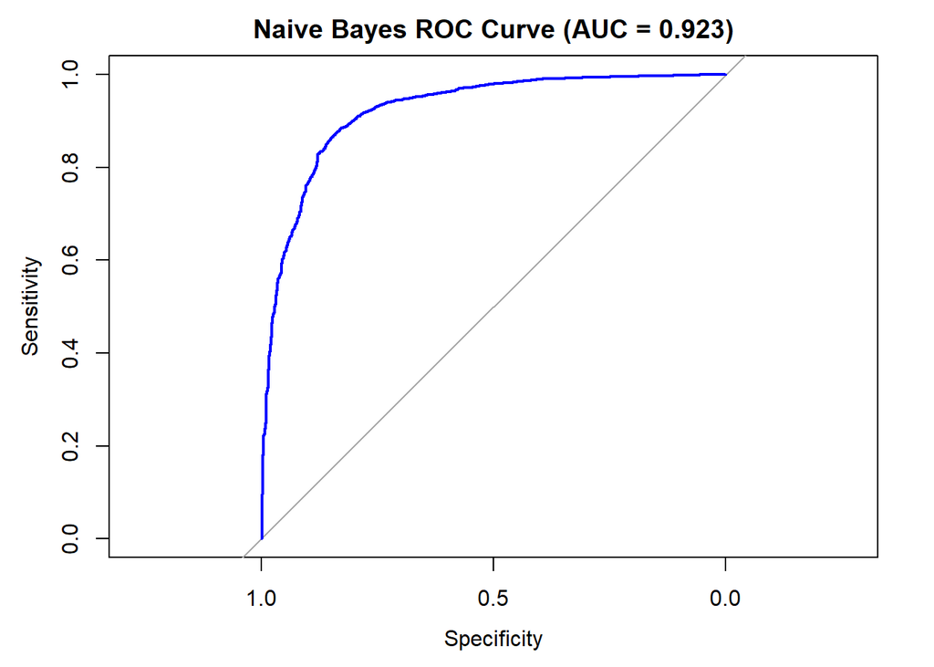

```r
plot(
  roc_nb,
  col = "blue",
  main = paste0(
    "Naive Bayes ROC Curve (AUC = ",
    round(auc_value, 3),
    ")"
  )
)
```

```r
png("NB_ROC.png", width = 1000, height = 800, res = 150)

plot(
  roc_nb,
  col = "blue",
  main = paste0(
    "Naive Bayes ROC Curve (AUC = ",
    round(auc_value, 3),
    ")"
  )
)

dev.off()
```

# 11. Save Model Performance Metrics

The final model performance is summarized using Accuracy, Kappa, Balanced Accuracy, Recall, Specificity, Precision, F1-score and AUC. Since the business focus is identifying loyalty-risk customers, Recall for `Not_Recommend` and Balanced Accuracy are important evaluation metrics.

```r
nb_metrics <- data.frame(
  Model = "Naive Bayes",
  Accuracy = as.numeric(nb_cm$overall["Accuracy"]),
  Kappa = as.numeric(nb_cm$overall["Kappa"]),
  Balanced_Accuracy = as.numeric(nb_cm$byClass["Balanced Accuracy"]),
  Recall_NotRecommend = as.numeric(nb_cm$byClass["Sensitivity"]),
  Specificity_Recommend = as.numeric(nb_cm$byClass["Specificity"]),
  Precision_NotRecommend = as.numeric(nb_cm$byClass["Pos Pred Value"]),
  F1_NotRecommend = as.numeric(nb_cm$byClass["F1"]),
  AUC = as.numeric(auc_value),
  Removed_NZV_Features = length(nzv_cols)
)

nb_metrics
```

```
##         Model  Accuracy    Kappa Balanced_Accuracy Recall_NotRecommend
## 1 Naive Bayes 0.8407249 0.568148         0.8530405           0.8723577
##   Specificity_Recommend Precision_NotRecommend F1_NotRecommend       AUC
## 1             0.8337232               0.537306       0.6650139 0.9225398
##   Removed_NZV_Features
## 1                  144
```

```r
write_csv(nb_metrics, "NB_Metrics.csv")
```

# 12. Save Final Model

The trained Naive Bayes model is saved as an RDS file so that it can be reused later for prediction or model deployment.

```r
saveRDS(nb_model, "NB_Model.rds")
```

# 13. Conclusion

The Naive Bayes model was developed to predict whether customers would recommend a clothing item. It is a useful baseline classification model because it is simple, fast and able to generate class probabilities. However, its final suitability should be judged based on the model evaluation metrics, especially Recall for `Not_Recommend`, Balanced Accuracy and AUC. These metrics show how effectively the model identifies loyalty-risk customers and separates recommendation classes.